# EFW and Infant Mortality: Preliminary Analysis

Propensity Score Matching Estimates of Major Changes in Economic Freedom

Author

Geloso & Wilhelm

Published

May 7, 2026

# 1 Introduction

This is a preliminary analysis of the causal effect of large, sustained changes in economic freedom (EFW) on infant mortality outcomes (IM). The methodology draws from Callais & Young (2023) and Grier (2025), extending their propensity-score matching framework to infant mortality. I also include two measures that assess changes in the statistical uncertainty of each country’s estimates for IM: confidence interval (con_int = upper_limit - lower_limit) and relative precision (rp = [con_int/2]/IM).

This analysis forms the basis for two papers:

1. EFW changes on IM
2. EFW changes on estimate **precision** as a proxy for “state capacity” (other than the “size and scope of government” hokum)

I introduce two new methods to the “change in EFW” treatment effects that I didn’t see in the EFW treatment literature:

1. Examine EFW score **drops**. $\leftarrow$ seems more symmetrical and we’d expect to see changes in the corresponding (but opposite) direction. This examines the “liberalism failures” as well as the successes.
2. Examine EFW **rank** changes. $\leftarrow$ I’ve seen a lot of comments/push-back on the validity of the EFW index score. Changes to the relative **rank** of a country short-circuits reviewer comments overly concerned with “EFW data issues”. Changes in relative rank will not capture changes in secular, worldwide trends of liberalisation. This analysis can “be in our back pocket” if we encounter such a reviewer.

**Outcomes** (5-year periods):

1. $\Delta\text{IM}$ — change in infant mortality rate (per 1,000 live births)
2. $\Delta\text{con\_int}$ — change in confidence interval width ($\text{IM\_upper} - \text{IM\_lower}$)
3. $\Delta\text{rp}$ — change in relative precision $= (\text{con\_int}/2)\,/\,\text{IM}$

For $\Delta\text{IM}$, a *negative* ATT indicates a sustained EFW liberalisation event is associated with a *larger decline* in infant mortality among treated countries.

# 2 Summary Statistics

Summary statistics — full estimation sample

| Variable | Mean | Std. Dev. | Min | Max |
| --- | --- | --- | --- | --- |
| **Outcome variables** |  |  |  |  |
| infantmortality | 41.678 | 39.021 | 1.910 | 175.116 |
| con_int | 7.198 | 8.410 | 0.074 | 66.708 |
| rp | 0.074 | 0.061 | 0.014 | 0.688 |
| **EFW change variables** |  |  |  |  |
| EFWdiff | 0.139 | 0.542 | -2.430 | 2.850 |
| EFWrankdiff | 1.964 | 15.078 | -67.000 | 79.000 |
| **PSM covariates** |  |  |  |  |
| lagEFW | 6.096 | 1.371 | 2.350 | 9.320 |
| laghc | 2.191 | 0.710 | 1.015 | 3.703 |
| laglngdppc | 8.848 | 1.173 | 6.059 | 11.445 |
| laggdpc_5growth | 0.122 | 0.225 | -1.347 | 1.545 |
| lagfertilrate | 3.637 | 1.978 | 0.959 | 8.461 |
| lagoldagedep | 11.439 | 6.711 | 0.796 | 35.073 |
| lagpolity2 | 2.847 | 7.079 | -10.000 | 10.000 |
| lagurbanpop | 53.771 | 23.536 | 2.845 | 100.000 |

# 3 Definitions of EFW Treatments

We identify four types of EFW events in a 5-year panel from 1970 to 2015. Treatments are constructed in `1) Import_Merge.R` and grouped by economic interpretation:

| Group | Treatment | Definition | Interpretation |
| --- | --- | --- | --- |
| **A** | **EFW Score Jump** | EFW index rose $\geq +1.0$ point over 5 years | Liberalisation |
| **A** | **EFW Rank Drop** | EFW rank improved $\geq 17$ places (lower rank = more free) | Liberalisation |
| **B** | **EFW Score Drop** | EFW index fell $\leq -1.0$ point over 5 years | Restriction |
| **B** | **EFW Rank Jump** | EFW rank worsened $\geq 17$ places | Restriction |

**Note**

We can modify the “rank change” cutoff to identify treatment. I chose 17 because there are 162 countries in EFW. A 1/10th change is equivalent to a change in relative rankings by 162/10 rounded up.

Observations adjacent to any qualifying event within the same country are set to NA (lag 1, lag 2, lead 1) to avoid contamination from overlapping reform episodes (Callais & Young 2023). Venezuela 2000 is excluded as a structural break. (I follow Callais & Young exaclty here. We can alter accordingly if you see fit.)

## 3.1 Treatment Episodes — Group A: Liberalisation

### 3.1.1 EFW Score Jumps ($\Delta\text{EFW} \geq +1.0$)

Table 1: EFW Score Jump episodes (N = 42). Sorted by magnitude of EFW increase.

| Country | Period | EFW Change |
| --- | --- | --- |
| Nicaragua | 1990-1995 | 2.85 |
| Argentina | 1990-1995 | 2.14 |
| El Salvador | 1990-1995 | 2.02 |
| Romania | 2000-2005 | 1.79 |
| Tanzania | 1990-1995 | 1.69 |
| Kuwait | 1980-1985 | 1.65 |
| Bolivia | 1985-1990 | 1.62 |
| Dominican Republic | 1990-1995 | 1.62 |
| Bulgaria | 2000-2005 | 1.52 |
| Costa Rica | 1985-1990 | 1.47 |
| Paraguay | 1990-1995 | 1.47 |
| Mauritius | 1980-1985 | 1.46 |
| Ghana | 1985-1990 | 1.39 |
| Poland | 1990-1995 | 1.38 |
| Iceland | 1985-1990 | 1.34 |
| Myanmar | 2010-2015 | 1.34 |
| Trinidad and Tobago | 1990-1995 | 1.31 |
| Croatia | 1995-2000 | 1.30 |
| Rwanda | 1995-2000 | 1.30 |
| Haiti | 1990-1995 | 1.28 |
| Malta | 1990-1995 | 1.23 |
| Portugal | 1975-1980 | 1.17 |
| Russian Federation | 1990-1995 | 1.17 |
| Latvia | 1995-2000 | 1.16 |
| Mexico | 1985-1990 | 1.15 |
| Lithuania | 1995-2000 | 1.13 |
| Nigeria | 1995-2000 | 1.13 |
| Türkiye | 1980-1985 | 1.10 |
| Chile | 1975-1980 | 1.09 |
| Madagascar | 1995-2000 | 1.08 |
| Benin | 1985-1990 | 1.07 |
| Guatemala | 1990-1995 | 1.07 |
| Hungary | 1990-1995 | 1.07 |
| Jordan | 1995-2000 | 1.07 |
| Brazil | 1985-1990 | 1.04 |
| New Zealand | 1985-1990 | 1.04 |
| Angola | 2005-2010 | 1.04 |
| Togo | 1980-1985 | 1.03 |
| Ukraine | 1995-2000 | 1.03 |
| South Africa | 1990-1995 | 1.02 |
| Belize | 2000-2005 | 1.02 |
| Bangladesh | 1995-2000 | 1.00 |

### 3.1.2 EFW Rank Drops: Relative Rank Improved $\geq 17$ Places

Table 2: EFW Rank Drop episodes (N = 68). Sorted by size of rank improvement (most negative first).

| Country | Period | Rank Change |
| --- | --- | --- |
| Romania | 2000-2005 | -67 |
| Argentina | 1990-1995 | -51 |
| Kuwait | 1980-1985 | -49 |
| Nicaragua | 1990-1995 | -46 |
| El Salvador | 1990-1995 | -43 |
| Estonia | 1995-2000 | -43 |
| Bolivia | 1985-1990 | -42 |
| Portugal | 1975-1980 | -40 |
| Malaysia | 2010-2015 | -36 |
| Ecuador | 1970-1975 | -35 |
| Philippines | 1985-1990 | -35 |
| Dominican Republic | 1975-1980 | -34 |
| Mauritius | 1980-1985 | -34 |
| Mexico | 1985-1990 | -34 |
| Lithuania | 1995-2000 | -32 |
| Belize | 2000-2005 | -32 |
| Montenegro | 2005-2010 | -32 |
| Latvia | 1995-2000 | -31 |
| Togo | 1980-1985 | -30 |
| Senegal | 1970-1975 | -29 |
| Chile | 1975-1980 | -28 |
| Israel | 1985-1990 | -28 |
| Tanzania | 1990-1995 | -28 |
| Jordan | 1995-2000 | -28 |
| Rwanda | 2005-2010 | -28 |
| Cabo Verde | 2010-2015 | -28 |
| Iceland | 2010-2015 | -27 |
| Mali | 1975-1980 | -26 |
| Indonesia | 1980-1985 | -26 |
| Benin | 1985-1990 | -26 |
| Paraguay | 1990-1995 | -26 |
| Cyprus | 2000-2005 | -26 |
| Ghana | 2000-2005 | -26 |
| Jordan | 1975-1980 | -25 |
| Georgia | 2000-2005 | -25 |
| Sierra Leone | 2005-2010 | -25 |
| Guatemala | 1985-1990 | -24 |
| Poland | 1990-1995 | -22 |
| Brazil | 2000-2005 | -22 |
| Türkiye | 2005-2010 | -22 |
| Lesotho | 2010-2015 | -22 |
| Rwanda | 1980-1985 | -21 |
| Türkiye | 1980-1985 | -21 |
| Iceland | 1985-1990 | -21 |
| Haiti | 1990-1995 | -21 |
| Croatia | 1995-2000 | -21 |
| Nigeria | 2000-2005 | -21 |
| Ecuador | 1985-1990 | -20 |
| Guatemala | 1970-1975 | -19 |
| Kenya | 1970-1975 | -19 |
| Nepal | 1975-1980 | -19 |
| Zambia | 1975-1980 | -19 |
| Gabon | 1980-1985 | -19 |
| Jamaica | 1980-1985 | -19 |
| Costa Rica | 1985-1990 | -19 |
| Zambia | 1995-2000 | -19 |
| Slovak Republic | 2000-2005 | -19 |
| Bosnia and Herzegovina | 2010-2015 | -19 |
| Nicaragua | 1970-1975 | -18 |
| Chad | 1980-1985 | -18 |
| Kenya | 2000-2005 | -18 |
| Malta | 2000-2005 | -18 |
| Kazakhstan | 2010-2015 | -18 |
| Zimbabwe | 2010-2015 | -18 |
| Iran, Islamic Rep. | 1970-1975 | -17 |
| Hungary | 1990-1995 | -17 |
| Croatia | 2010-2015 | -17 |
| Sri Lanka | 2010-2015 | -17 |

## 3.2 Treatment Episodes — Group B: Restriction

### 3.2.1 EFW Score Drops ($\Delta\text{EFW} \leq -1.0$)

Table 3: EFW Score Drop episodes (N = 21). Sorted by magnitude of EFW decrease.

| Country | Period | EFW Change |
| --- | --- | --- |
| Argentina | 1970-1975 | -2.43 |
| Rwanda | 1970-1975 | -1.77 |
| Iran, Islamic Rep. | 1975-1980 | -1.65 |
| Mauritius | 1970-1975 | -1.60 |
| Burundi | 1970-1975 | -1.58 |
| Iceland | 2005-2010 | -1.44 |
| Uruguay | 1970-1975 | -1.32 |
| Honduras | 1975-1980 | -1.17 |
| Mexico | 1975-1980 | -1.17 |
| Pakistan | 1970-1975 | -1.16 |
| Argentina | 2000-2005 | -1.15 |
| Madagascar | 1970-1975 | -1.14 |
| Ecuador | 1980-1985 | -1.14 |
| Poland | 1980-1985 | -1.13 |
| Iceland | 1970-1975 | -1.09 |
| Zambia | 1970-1975 | -1.09 |
| Malawi | 1970-1975 | -1.07 |
| Costa Rica | 1970-1975 | -1.06 |
| Fiji | 1970-1975 | -1.06 |
| El Salvador | 1975-1980 | -1.04 |
| Peru | 1970-1975 | -1.03 |

### 3.2.2 EFW Rank Jumps: Relative Rank Worsened $\geq 17$ Places

Table 4: EFW Rank Jump episodes (N = 77). Sorted by size of rank worsening (most positive first).

| Country | Period | Rank Change |
| --- | --- | --- |
| Iceland | 2005-2010 | 66 |
| Argentina | 1970-1975 | 57 |
| Iran, Islamic Rep. | 1975-1980 | 57 |
| Congo, Rep. | 1995-2000 | 54 |
| Ecuador | 1980-1985 | 45 |
| Poland | 1980-1985 | 41 |
| Guatemala | 1980-1985 | 37 |
| Belize | 1995-2000 | 37 |
| Greece | 2010-2015 | 37 |
| Togo | 1990-1995 | 36 |
| Rwanda | 1970-1975 | 35 |
| Romania | 1985-1990 | 35 |
| Sri Lanka | 2000-2005 | 35 |
| El Salvador | 1975-1980 | 34 |
| Jordan | 1985-1990 | 34 |
| Benin | 1990-1995 | 34 |
| Congo, Dem. Rep. | 1995-2000 | 34 |
| Ecuador | 1995-2000 | 34 |
| Burundi | 1970-1975 | 33 |
| Myanmar | 1995-2000 | 32 |
| Russian Federation | 1995-2000 | 31 |
| Indonesia | 1995-2000 | 30 |
| Côte d'Ivoire | 2005-2010 | 30 |
| Honduras | 1975-1980 | 29 |
| Fiji | 1985-1990 | 29 |
| Guinea-Bissau | 1995-2000 | 29 |
| Malaysia | 1995-2000 | 29 |
| Tunisia | 2005-2010 | 29 |
| Syrian Arab Republic | 1995-2000 | 28 |
| Mauritius | 1970-1975 | 27 |
| Saudi Arabia | 2010-2015 | 27 |
| India | 1970-1975 | 26 |
| Pakistan | 1995-2000 | 26 |
| Tanzania | 2000-2005 | 25 |
| Ghana | 2010-2015 | 25 |
| Zambia | 1970-1975 | 24 |
| Kuwait | 1975-1980 | 24 |
| Azerbaijan | 2005-2010 | 24 |
| India | 2005-2010 | 24 |
| Brazil | 2010-2015 | 24 |
| Zambia | 2010-2015 | 24 |
| Colombia | 1985-1990 | 23 |
| Haiti | 1985-1990 | 23 |
| Guatemala | 1995-2000 | 23 |
| Egypt, Arab Rep. | 2000-2005 | 23 |
| Norway | 2010-2015 | 23 |
| Sierra Leone | 2010-2015 | 23 |
| Malawi | 1970-1975 | 22 |
| Türkiye | 1975-1980 | 22 |
| Jamaica | 1975-1980 | 21 |
| Botswana | 1980-1985 | 21 |
| Philippines | 1980-1985 | 21 |
| Tanzania | 1980-1985 | 21 |
| Iran, Islamic Rep. | 1990-1995 | 21 |
| Senegal | 1990-1995 | 21 |
| Ukraine | 1995-2000 | 21 |
| Togo | 2005-2010 | 21 |
| Paraguay | 1980-1985 | 20 |
| Bulgaria | 1985-1990 | 20 |
| Algeria | 1995-2000 | 20 |
| Bangladesh | 2000-2005 | 20 |
| Botswana | 2005-2010 | 20 |
| Iran, Islamic Rep. | 2005-2010 | 20 |
| Pakistan | 1970-1975 | 19 |
| Uruguay | 1970-1975 | 19 |
| Morocco | 1995-2000 | 19 |
| Haiti | 2000-2005 | 19 |
| South Africa | 2010-2015 | 19 |
| Bolivia | 1980-1985 | 18 |
| Ghana | 1995-2000 | 18 |
| Senegal | 2005-2010 | 18 |
| Dominican Republic | 1970-1975 | 17 |
| Egypt, Arab Rep. | 1980-1985 | 17 |
| Greece | 1980-1985 | 17 |
| China | 1985-1990 | 17 |
| Trinidad and Tobago | 2005-2010 | 17 |
| Uruguay | 2010-2015 | 17 |

# 4 PSM Methodology

## 4.1 Three Matching Estimators

For each treatment $\times$ outcome combination we estimate the Average Treatment Effect on the Treated (ATT) using three matching specifications. All three condition on the same vector of pre-treatment covariates (see Covariates below). Differences across the three estimators provide a robustness check; agreement across them strengthens the causal interpretation.

### 4.1.1 1. PSM — 3 Nearest Neighbors (NN3)

A logistic regression of the binary treatment on the covariate vector produces a **propensity score** for each observation. Each treated unit is then matched to its 3 nearest control units on the propensity score within a caliper of 0.25 standard deviations (Austin 2011). Matching is done *without replacement*: each control unit can serve as a match for only one treated unit. The ATT is the average outcome difference between treated units and their matched controls. Standard errors are computed by non-parametric bootstrap (200 replications, seed 50726).

### 4.1.2 2. PSM — Epanechnikov Kernel

Same logit-based propensity score as NN3, but each treated unit is compared to a *weighted average* of all control units, where the weights follow an Epanechnikov kernel function (declining smoothly with PS distance). This estimator uses information from many controls per treated unit, trading some variance reduction for reliance on the kernel specification. Standard errors by bootstrap (200 replications).

### 4.1.3 3. Mahalanobis NN3 with Bias Adjustment

Skips the propensity-score model entirely. Each treated unit is matched to its 3 nearest controls in the **full covariate space** using Mahalanobis distance (which accounts for covariance among covariates)[^1]. An Abadie-Imbens (2011) bias correction is applied via regression adjustment. Standard errors are computed analytically. Matching is done *with replacement*, so a strong control unit can match several treated units.

## 4.2 Covariates

Each treatment regression conditions on the following pre-treatment covariates (all lagged one 5-year period to ensure measurement before the treatment event, following Callais & Young 2023 and the existing Stata pipeline `Results_DecileGrowth5yr.do`)[^2]:

| Covariate | Description | Source |
| --- | --- | --- |
| `lagEFW` | EFW summary index (lagged) | Fraser Institute |
| `laghc` | Human capital index | Penn World Tables |
| `laglngdppc` | Log GDP per capita | Penn World Tables |
| `laglngdppc2` | Log GDP per capita squared | Penn World Tables |
| `laggdpc_5growth` | 5-year GDP per capita growth | Penn World Tables |
| `lagfertilrate` | Fertility rate | World Bank WDI |
| `lagoldagedep` | Old-age dependency ratio | World Bank WDI |
| `lagpolity2` | Polity2 democracy score | Polity5 |
| `lagurbanpop` | Urban population share | World Bank WDI |
| Lagged outcome | Lagged level of the specific regression’s outcome | UNICEF |

**Warning**

Covariates listed above may be subject to change. See “Caveats” below.

# 5 PSM Results

A **negative ATT** for $\Delta\text{IM}$ indicates that treated countries saw a *larger decline* in infant mortality than comparable untreated countries — a beneficial effect.

## 5.1 EFW Score Jump

*EFW score increased >= 1.0 point (5-year change)*

**Outcome: Infant Mortality Rate**

ATT of EFW Score Jump on Infant Mortality Rate

| Estimator | N Treated | ATT | SE | 95% CI |
| --- | --- | --- | --- | --- |
| PSM NN3 | 27 | -3.2741** | (1.3834) | [-5.9856, -0.5627] |
| PSM Kernel | 33 | -2.0410 | (1.7769) | [-5.5238, 1.4418] |
| Mahalanobis NN3 (BA) | 38 | -3.0625*** | (0.9705) | [-4.9646, -1.1604] |

Notes: Bootstrap SE (200 reps) for PSM NN3 and PSM Kernel; Abadie-Imbens SE for Mahalanobis. *** p<0.01, ** p<0.05, * p<0.10.

**Outcome: CI Width (con_int)**

ATT of EFW Score Jump on CI Width (con_int)

| Estimator | N Treated | ATT | SE | 95% CI |
| --- | --- | --- | --- | --- |
| PSM NN3 | 27 | 0.8586 | (0.8379) | [-0.7838, 2.5009] |
| PSM Kernel | 35 | 0.7363 | (0.8084) | [-0.8482, 2.3208] |
| Mahalanobis NN3 (BA) | 38 | 0.8358 | (0.6282) | [-0.3954, 2.0670] |

Notes: Bootstrap SE (200 reps) for PSM NN3 and PSM Kernel; Abadie-Imbens SE for Mahalanobis. *** p<0.01, ** p<0.05, * p<0.10.

**Outcome: Relative Precision (rp)**

ATT of EFW Score Jump on Relative Precision (rp)

| Estimator | N Treated | ATT | SE | 95% CI |
| --- | --- | --- | --- | --- |
| PSM NN3 | 26 | 0.0103 | (0.0078) | [-0.0049, 0.0255] |
| PSM Kernel | 34 | 0.0123* | (0.0070) | [-0.0014, 0.0260] |
| Mahalanobis NN3 (BA) | 38 | 0.0091 | (0.0066) | [-0.0038, 0.0220] |

Notes: Bootstrap SE (200 reps) for PSM NN3 and PSM Kernel; Abadie-Imbens SE for Mahalanobis. *** p<0.01, ** p<0.05, * p<0.10.

## 5.2 EFW Rank Drop

*EFW rank improved >= 17 places (lower rank = more free)*

**Outcome: Infant Mortality Rate**

ATT of EFW Rank Drop on Infant Mortality Rate

| Estimator | N Treated | ATT | SE | 95% CI |
| --- | --- | --- | --- | --- |
| PSM NN3 | 57 | -2.5938*** | (0.9740) | [-4.5028, -0.6848] |
| PSM Kernel | 58 | -2.7293 | (1.7081) | [-6.0772, 0.6186] |
| Mahalanobis NN3 (BA) | 59 | -2.4812*** | (0.9311) | [-4.3062, -0.6561] |

Notes: Bootstrap SE (200 reps) for PSM NN3 and PSM Kernel; Abadie-Imbens SE for Mahalanobis. *** p<0.01, ** p<0.05, * p<0.10.

**Outcome: CI Width (con_int)**

ATT of EFW Rank Drop on CI Width (con_int)

| Estimator | N Treated | ATT | SE | 95% CI |
| --- | --- | --- | --- | --- |
| PSM NN3 | 54 | -0.3626 | (0.4619) | [-1.2679, 0.5426] |
| PSM Kernel | 58 | -0.3823 | (0.7096) | [-1.7731, 1.0085] |
| Mahalanobis NN3 (BA) | 59 | -0.5561 | (0.4403) | [-1.4192, 0.3069] |

Notes: Bootstrap SE (200 reps) for PSM NN3 and PSM Kernel; Abadie-Imbens SE for Mahalanobis. *** p<0.01, ** p<0.05, * p<0.10.

**Outcome: Relative Precision (rp)**

ATT of EFW Rank Drop on Relative Precision (rp)

| Estimator | N Treated | ATT | SE | 95% CI |
| --- | --- | --- | --- | --- |
| PSM NN3 | 53 | 0.0026 | (0.0031) | [-0.0035, 0.0087] |
| PSM Kernel | 58 | 0.0016 | (0.0040) | [-0.0063, 0.0094] |
| Mahalanobis NN3 (BA) | 59 | 0.0026 | (0.0023) | [-0.0019, 0.0072] |

Notes: Bootstrap SE (200 reps) for PSM NN3 and PSM Kernel; Abadie-Imbens SE for Mahalanobis. *** p<0.01, ** p<0.05, * p<0.10.

## 5.3 EFW Score Drop

*EFW score decreased >= 1.0 point (5-year change)*

**Outcome: Infant Mortality Rate**

ATT of EFW Score Drop on Infant Mortality Rate

| Estimator | N Treated | ATT | SE | 95% CI |
| --- | --- | --- | --- | --- |
| PSM NN3 | 14 | 4.5432 | (2.9849) | [-1.3073, 10.3936] |
| PSM Kernel | 18 | 1.5281 | (3.4988) | [-5.3296, 8.3857] |
| Mahalanobis NN3 (BA) | 19 | 0.1297 | (2.6685) | [-5.1007, 5.3600] |

Notes: Bootstrap SE (200 reps) for PSM NN3 and PSM Kernel; Abadie-Imbens SE for Mahalanobis. *** p<0.01, ** p<0.05, * p<0.10.

**Outcome: CI Width (con_int)**

ATT of EFW Score Drop on CI Width (con_int)

| Estimator | N Treated | ATT | SE | 95% CI |
| --- | --- | --- | --- | --- |
| PSM NN3 | 15 | 0.0098 | (0.8664) | [-1.6884, 1.7080] |
| PSM Kernel | 17 | -1.2323 | (1.3935) | [-3.9635, 1.4989] |
| Mahalanobis NN3 (BA) | 19 | -0.8258 | (0.5039) | [-1.8134, 0.1619] |

Notes: Bootstrap SE (200 reps) for PSM NN3 and PSM Kernel; Abadie-Imbens SE for Mahalanobis. *** p<0.01, ** p<0.05, * p<0.10.

**Outcome: Relative Precision (rp)**

ATT of EFW Score Drop on Relative Precision (rp)

| Estimator | N Treated | ATT | SE | 95% CI |
| --- | --- | --- | --- | --- |
| PSM NN3 | 15 | -0.0060 | (0.0056) | [-0.0169, 0.0049] |
| PSM Kernel | 17 | -0.0057 | (0.0070) | [-0.0193, 0.0080] |
| Mahalanobis NN3 (BA) | 19 | -0.0076*** | (0.0025) | [-0.0124, -0.0028] |

Notes: Bootstrap SE (200 reps) for PSM NN3 and PSM Kernel; Abadie-Imbens SE for Mahalanobis. *** p<0.01, ** p<0.05, * p<0.10.

## 5.4 EFW Rank Jump

*EFW rank worsened >= 17 places (higher rank = less free)*

**Outcome: Infant Mortality Rate**

ATT of EFW Rank Jump on Infant Mortality Rate

| Estimator | N Treated | ATT | SE | 95% CI |
| --- | --- | --- | --- | --- |
| PSM NN3 | 72 | 0.9593 | (1.0750) | [-1.1477, 3.0662] |
| PSM Kernel | 73 | 0.3960 | (1.4140) | [-2.3755, 3.1675] |
| Mahalanobis NN3 (BA) | 73 | 0.7083 | (0.9076) | [-1.0706, 2.4871] |

Notes: Bootstrap SE (200 reps) for PSM NN3 and PSM Kernel; Abadie-Imbens SE for Mahalanobis. *** p<0.01, ** p<0.05, * p<0.10.

**Outcome: CI Width (con_int)**

ATT of EFW Rank Jump on CI Width (con_int)

| Estimator | N Treated | ATT | SE | 95% CI |
| --- | --- | --- | --- | --- |
| PSM NN3 | 72 | 0.0970 | (0.3938) | [-0.6748, 0.8689] |
| PSM Kernel | 73 | 0.5483 | (0.6308) | [-0.6880, 1.7846] |
| Mahalanobis NN3 (BA) | 73 | -0.1341 | (0.3264) | [-0.7739, 0.5057] |

Notes: Bootstrap SE (200 reps) for PSM NN3 and PSM Kernel; Abadie-Imbens SE for Mahalanobis. *** p<0.01, ** p<0.05, * p<0.10.

**Outcome: Relative Precision (rp)**

ATT of EFW Rank Jump on Relative Precision (rp)

| Estimator | N Treated | ATT | SE | 95% CI |
| --- | --- | --- | --- | --- |
| PSM NN3 | 72 | -0.0026 | (0.0031) | [-0.0088, 0.0035] |
| PSM Kernel | 73 | 0.0022 | (0.0057) | [-0.0091, 0.0134] |
| Mahalanobis NN3 (BA) | 73 | -0.0002 | (0.0031) | [-0.0064, 0.0059] |

Notes: Bootstrap SE (200 reps) for PSM NN3 and PSM Kernel; Abadie-Imbens SE for Mahalanobis. *** p<0.01, ** p<0.05, * p<0.10.

# 6 Balance & Distribution Diagnostics

Balance diagnostics restricted to the two outcomes specified in the analysis brief: **Infant Mortality Rate** ($\Delta\text{IM}$) and **Relative Precision** ($\Delta\text{rp}$). For each treatment we show:

1. **Propensity-score density plot** — kernel density of the estimated propensity score for treated and control units, before vs after PSM NN3 matching. Better overlap on the right panel = better matched-sample comparability.
2. **Love plot** — standardized mean differences (SMDs) for each PSM covariate, before vs after matching. Dashed reference lines at $\pm 0.10$ mark the threshold below which a covariate is conventionally considered well balanced (Austin 2011).

## EFW Score Jump

### Outcome: Infant Mortality Rate

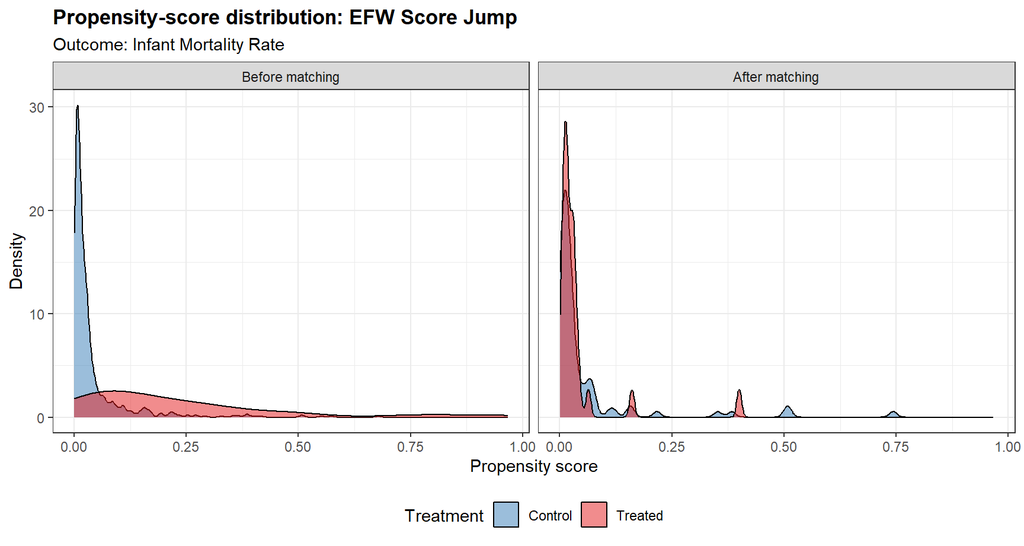

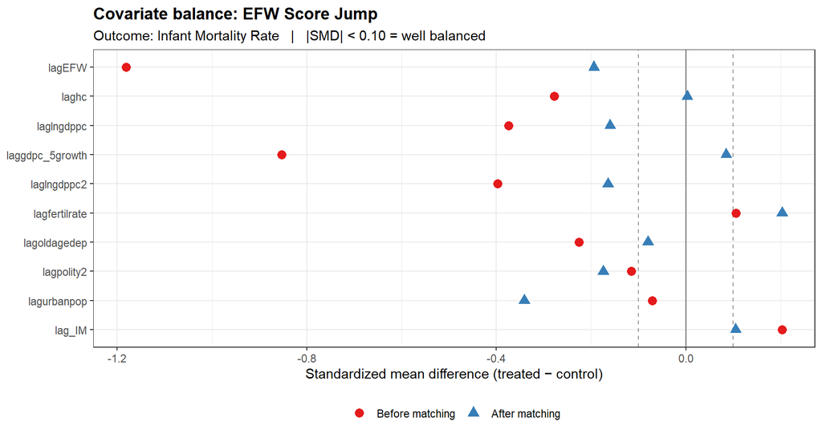

### Outcome: Relative Precision (rp)

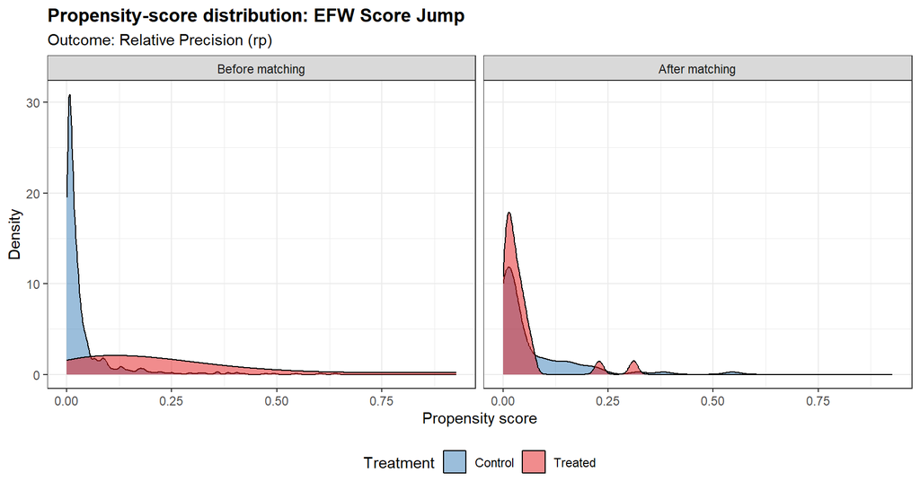

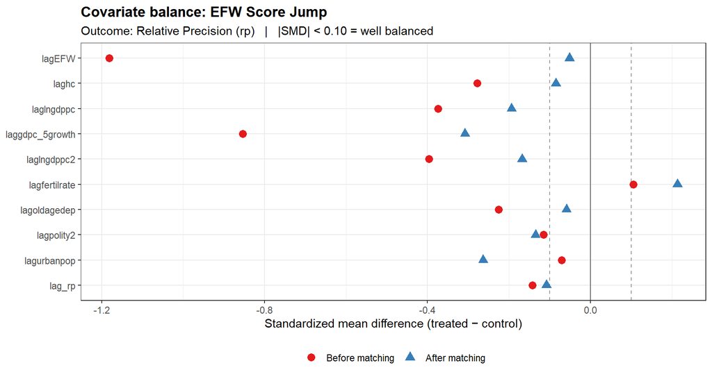

## EFW Rank Drop

### Outcome: Infant Mortality Rate

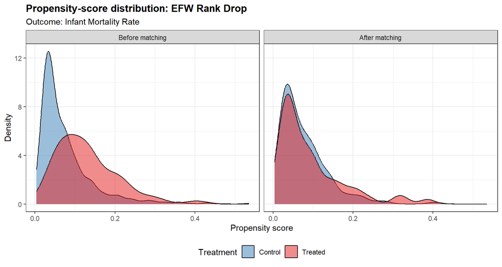

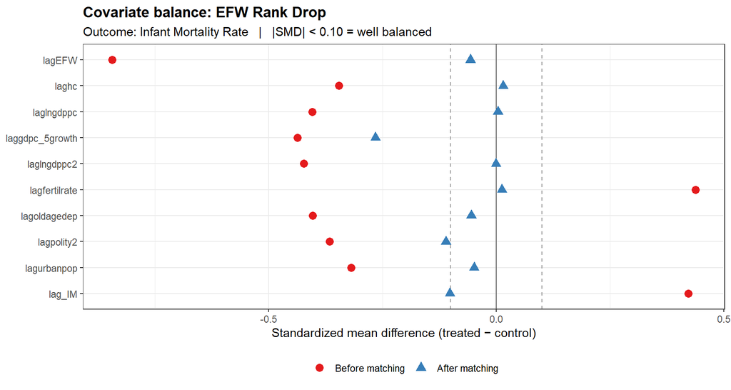

### Outcome: Relative Precision (rp)

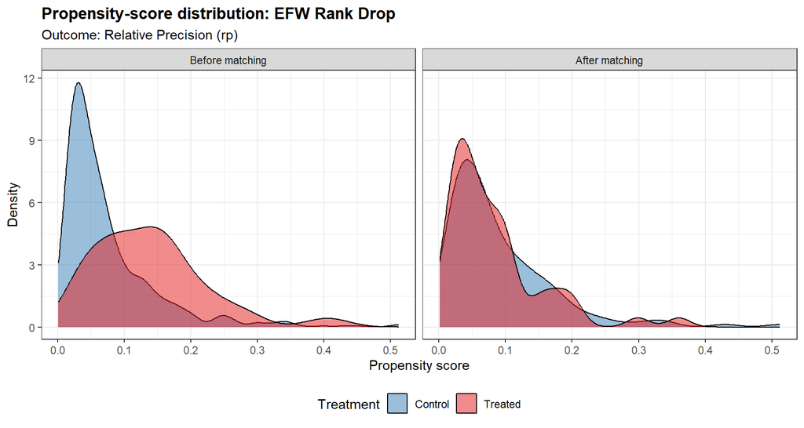

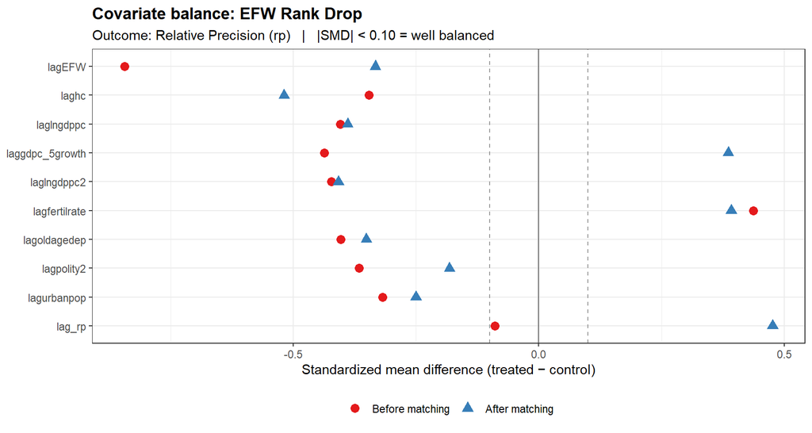

## EFW Score Drop

### Outcome: Infant Mortality Rate

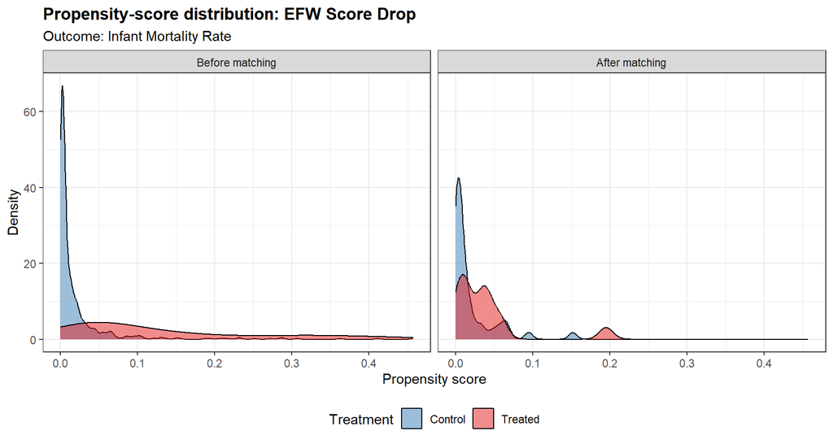

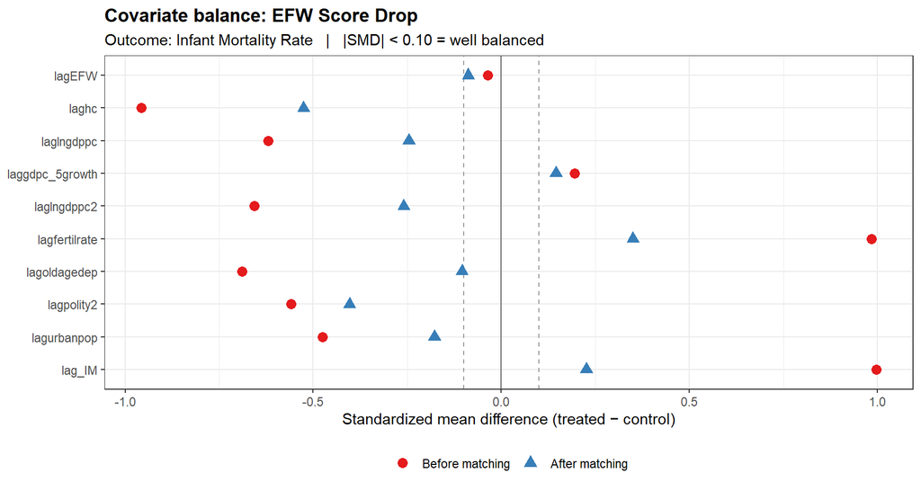

### Outcome: Relative Precision (rp)

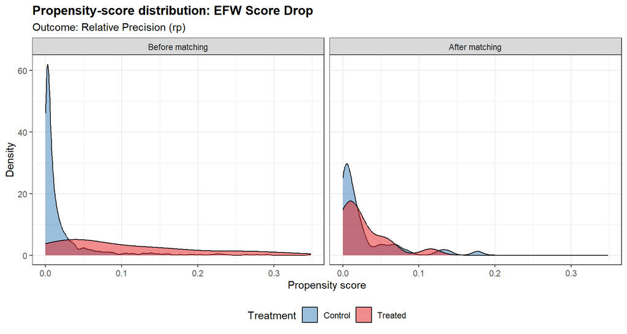

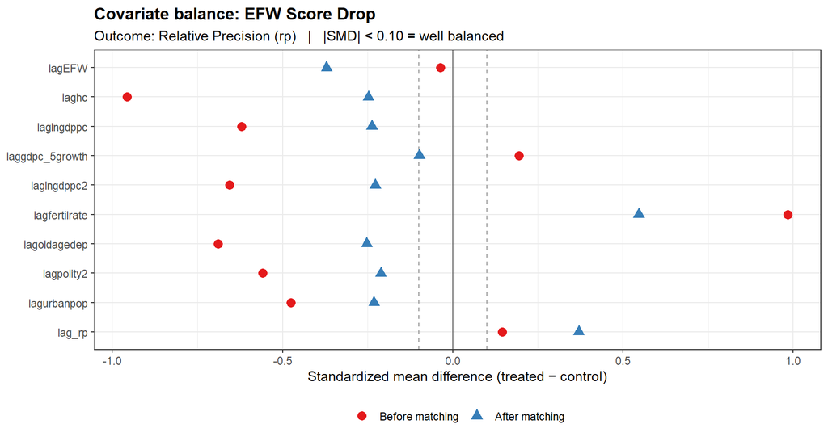

## EFW Rank Jump

### Outcome: Infant Mortality Rate

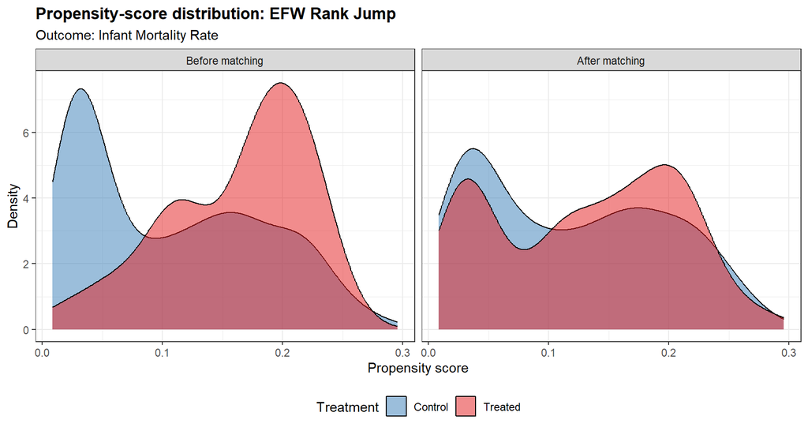

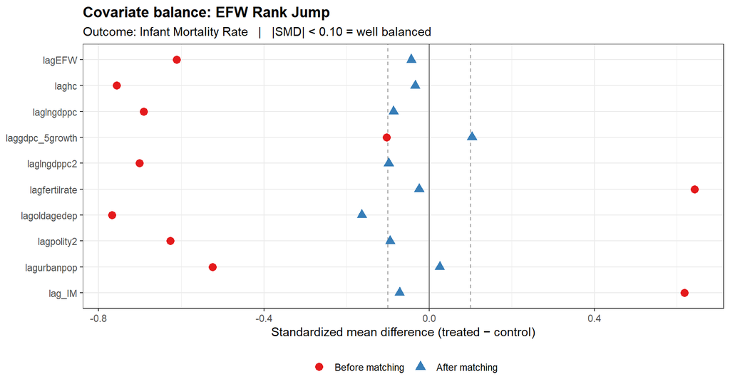